# R에서 공간 자료와 지도

서울시립대 통계학과 이용희

2019년 3월 14일

# 안내

공간자료인 지도(map)의 정보가 R에서 어떻게 구성되어 있는지 간단한 예제를 통해서 알아본다. 공간 및 지도자료의 구성과 분석에 대한 자세한 안내는 [Spatial Data Science with R](https://rspatial.org/index.html)에서 찾을 수 있다.

## 필요한 라이브러리와 예제 서울지도 불러오기

먼저 필요한 라이브러리(library)들을 실행시킨다. 만약에 필요한 라이브러리가 설치가 되어있지 않다면 `install.packages()` 명령을 통하여 먼저 실행한다. `install.packages()`는 최초 한번만 실행하면 라이브러리가 설치된다. 그 이후에 사용할 때마다 `library()` 명령을 통하여 불러오면 된다.

```r
library(sp)
library(rgdal)
library(RColorBrewer)
library(dplyr)
library(tidyr)
library(tmap)
library(raster)
```

- 참고: MS-windows 에서는 다음과 같은 경고가 나올 수도 있으며 무시한다. `Warning messages: 1: In strsplit(x, "\n") : input string 1 is invalid in this locale`

서울의 구별 행정구역 지도화일을 `R`프로그램으로 불러와서 `R`에서 사용할 수 있도록 한다. 함수 `load`를 이용하여 R 데이터 화일 **seoulmap.RData**을 불러오면 지도 객체 `seoul0`을 이용할 수 있다.

서울의 구별 행정구역 지도 객체는 `SpatialPolygonsDataFrame` 형식으로 지정된 `seoul0`에 저장되어있다.

```r
load("seoulmap.RData")
seoul0
```

```
## class       : SpatialPolygonsDataFrame
## features    : 25
## extent      : 126.7699, 127.1709, 37.41528, 37.66492  (xmin, xmax, ymin, ymax)
## coord. ref. : +proj=longlat +datum=WGS84 +no_defs +ellps=WGS84 +towgs84=0,0,0
## variables   : 3
## names       :       code, engname,   name
## min values  : 1111000000,  Dobong, 강남구
## max values  : 1174000000, Yongsan, 중랑구
```

## 공간자료의 구성

### 벡터데이터

공간에 대한 위치정보는 벡터(vector)형식으로 저장된다. 지도에서 한 곳의 위치를 나타낼 때 2개의 좌표, 즉 위도(latitude)와 경도(longitude)로 구성된 [지리 좌표계(Geographic coordinate system)](https://en.wikipedia.org/wiki/Geographic_coordinate_system) 를 사용한다.

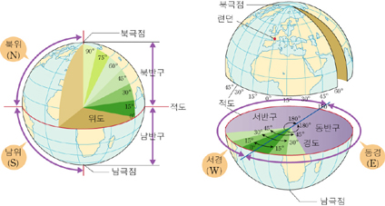

그림: 위도와 경도

예를 들면 서울 광화문의 위치를 지리 좌표계로 나타내면 위도와 경도는 37.5759 N, 126.9768 E 이다. 서울시립대의 위치는 37.5839 N, 127.0589 E 이며 고속터미날은 37.5048 N, 127.0049 E이다.

지도의 위치를 나타내는 방식은 벡터 자료를 이용하며 위치는 점(point), 점을 연결하는 선(line)과 다각형(polygon) 형식으로 저장된다. 패키지 `sp`에서 정의된 공각 자료 형식은 다음과 같다.

*`SpatialPoints`

*`SpatialLines`

*`SpatialPolygons`

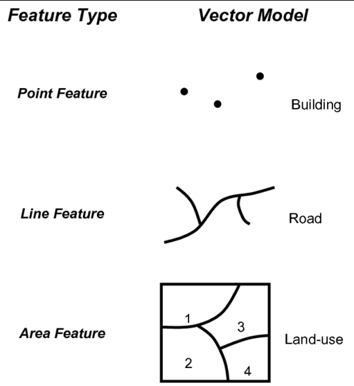

그림: 공간을 나타내는 벡터 자료의 형식

### SpatialPoints

지도의 한 위치를 나타내려면 위에서 본 것과 같이 위도와 경도로 구성된 좌표자료가 필요하며 이를 R에서 `SpatialPoints` 형식으로 저장한다. `SpatialPoints` 형식은 패키지 `sp`에서 정의한 형식이다.

이제 광화문, 서울시립대, 고속터미널의 위치를 지도 좌표계로 나타낼 수 있는 `SpatialPoints` 형식으로 만들어 보자. 위도와 경도들로 구성된 벡터를 만들고 두개의 벡터를 `cbind` 함수를 이용하여 합친다. 함수 `cbind`는 두 개의 벡터를 열 방향으로 합쳐주는 함수이다.

```r
longitude <- c(126.9768,127.0589, 127.0049)  # 경도
latitude <- c(37.5759, 37.5839, 37.5048)    # 위도
lonlat <- cbind(longitude, latitude) # 위도와 경도를 합친다.
lonlat
```

```
##      longitude latitude
## [1,]  126.9768  37.5759
## [2,]  127.0589  37.5839
## [3,]  127.0049  37.5048
```

이제 위도와 경도로 된 자료를 `SpatialPoints` 형식으로 만들어 보자.

```r
ptr <- SpatialPoints(lonlat)
ptr
```

```
## class       : SpatialPoints
## features    : 3
## extent      : 126.9768, 127.0589, 37.5048, 37.5839  (xmin, xmax, ymin, ymax)
## coord. ref. : NA
```

객체 `ptr`는 `SpatialPoints` 형식(class)을 가진 자료이다. 이제 `ptr`에 들어 있는 좌표를 함수 `coordinate` 로 볼 수 있다.

```r
coordinates(ptr)
```

```
##      longitude latitude
## [1,]  126.9768  37.5759
## [2,]  127.0589  37.5839
## [3,]  127.0049  37.5048
```

```r
proj4string(ptr) = CRS("+init=epsg:4326")
ptr
```

```
## class       : SpatialPoints
## features    : 3
## extent      : 126.9768, 127.0589, 37.5048, 37.5839  (xmin, xmax, ymin, ymax)
## coord. ref. : +init=epsg:4326 +proj=longlat +datum=WGS84 +no_defs +ellps=WGS84 +towgs84=0,0,0
```

이제 서울의 지도를 그리고 광화문, 시립대, 터미널의 위치를 빨간점으로 표시해 보자.

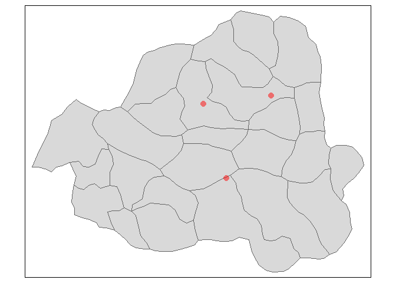

```r
tm_shape(seoul0) +    # SpatialPolygonsDataFrame(서울지도)를 지정한다.
tm_polygons(col = NA) +   # 서울지도를 그린다.
tm_shape(ptr)  +    # SpatialPoints(광화문,시립대,터미널)를 지정한다.
tm_dots(col="red",size = 0.5, alpha = 0.5) # 위치를 그린다.
```

### SpatialLines and SpatialPolygons

점들을 연결한 공간 자료의 형식이 `SpatialLines`이며 선들을 연결하여 닫힌 도형을 구성하는 것이 `SpatialPolygons`이다.

이제 `raster` 패키지에서 제공하는 `spPolygons`를 사용하여 광화문, 시립대, 터미널의 위치를 이어서 공간다각형(`SpatialPolygons`)을 만들어 보자. 세점을 이어주는 삼각형이 만들어 진다. 선택 명령문 `crs=CRS("+init=epsg:4326")`는 투영법을 지정하는 명령이다.

```r
plg <- spPolygons(lonlat, crs=CRS("+init=epsg:4326"))
plg
```

```
## class       : SpatialPolygons
## features    : 1
## extent      : 126.9768, 127.0589, 37.5048, 37.5839  (xmin, xmax, ymin, ymax)
## coord. ref. : +init=epsg:4326 +proj=longlat +datum=WGS84 +no_defs +ellps=WGS84 +towgs84=0,0,0
```

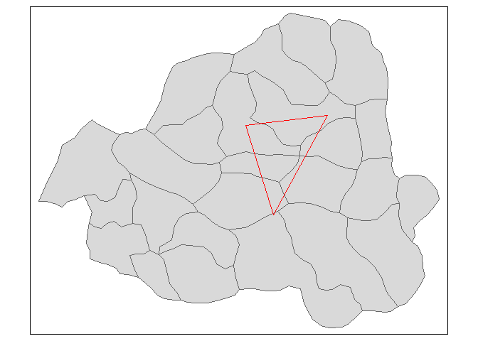

```r
tm_shape(seoul0) +    # SpatialPolygonsDataFrame(서울지도)를 지정한다.
tm_polygons(col = NA) +   # 서울지도를 그린다.
tm_shape(plg)  +    # SpatialPolygons  plg를 지정한다.
tm_borders(col = "red") # 다각형를 그린다.
```

## SpatialPolygonsDataFrame

```r
seoul0
```

```
## class       : SpatialPolygonsDataFrame
## features    : 25
## extent      : 126.7699, 127.1709, 37.41528, 37.66492  (xmin, xmax, ymin, ymax)
## coord. ref. : +proj=longlat +datum=WGS84 +no_defs +ellps=WGS84 +towgs84=0,0,0
## variables   : 3
## names       :       code, engname,   name
## min values  : 1111000000,  Dobong, 강남구
## max values  : 1174000000, Yongsan, 중랑구
```

지도 객체(map object) `seoul0`은 어떻게 구성되어 있는지 자료의 구성과 구조를 각각 `class` 과 `slotNames` 함수로 파악할 수 있다.

지도 객체(map object) `seoul0`은 `SpatialPolygonsDataFrame`이라는 클래스(class)로 정의되어 있으며 이는 `R`에서 지도 자료를 저장하는 기본적인 자료 형식이다.

```r
class(seoul0)
```

```
## [1] "SpatialPolygonsDataFrame"
## attr(,"package")
## [1] "sp"
```

또한 지도객체 `seoul0` 는 5개의 내부자료(slot 이라고 부른다)로 구성되어 있다. 이 내부자료는 함수 `slotNames`를 이용해서 어떤 이름으로 저장되어 있는지 알 수 있다. 내부자료 5개 중에서 `data`는 각 행정구역의 특성을 포함하는 데이터프레임(`dataframe`)이며 나머지 4개의 내부자료(`polygon`, `plotOrder`, `bbox`, `proj4string`)는 지도의 위치정보(점, 선, 경계 등)와 투영법(projection)에 대한 자료이다.

```r
slotNames(seoul0)
```

```
## [1] "data"        "polygons"    "plotOrder"   "bbox"        "proj4string"
```

지도 객체(map object) `seoul0`안에 포함된 실제 자료(data)는 `seoul0@data`에 저장되있으며  
그 안에 있는 자료의 일부를 함수 `head`를 통해서 볼 수 있다. 옵션 `n=10`는 처음 10개의 자료만 출력하라는 의미이다.

```r
head(seoul0@data,n=10)
```

```
##          code     engname     name
## 1  1132000000      Dobong   도봉구
## 2  1123000000 Dong-daemun 동대문구
## 3  1159000000     Dongjak   동작구
## 4  1138000000  Eun-pyeong   은평구
## 5  1174000000     Gandong   강동구
## 6  1130500000     Gangbuk   강북구
## 7  1168000000     Gangnam   강남구
## 8  1150000000     Gangseo   강서구
## 9  1154500000  Geum-cheon   금천구
## 10 1153000000        Guro   구로구
```

자료 `seoul0@data`에 들어 있는 각 변수들의 이름을 `names` 함수로 볼 수 있다.

```r
names(seoul0@data)
```

```
## [1] "code"    "engname" "name"
```

- `code` : 행정구역코드(구)
- `engname`: 영어 행정구역 이름(구)
- `name` : 한글행정구역 이름(구)

아제 서울시 구별 경계 지도를 그려보면

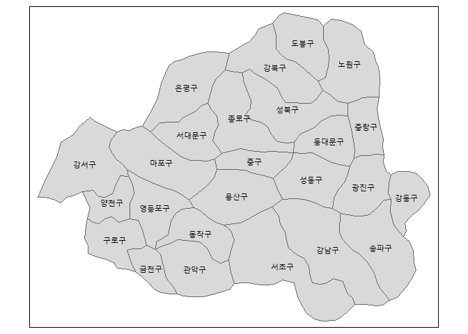

```r
tm_shape(seoul0) +    # SpatialPolygonsDataFrame(서울지도)를 지정한다.
tm_polygons(col = NA) +    # 서울지도를 그린다.
tm_text(text = "name",size=0.7)  # 구이름을 표시한다.
```

아래에서 사용한 함수 `qtm`은 아래와 같은 명령문을 간단하게 축약한 명령어이다.

함수 `qtm`를 이용하여 서울의 구경계지도를 그려보자. 지도를 그리는 경우 함수 `qtm`의 선택명령어 `text = "name"` 위에서 생성한 각 구의 한글이름을 출력한다. 또한 구 이름의 문자 크기는 선택명령어 `text.size = 0.7`에 있는 비율값으로 조정할 수 있다.

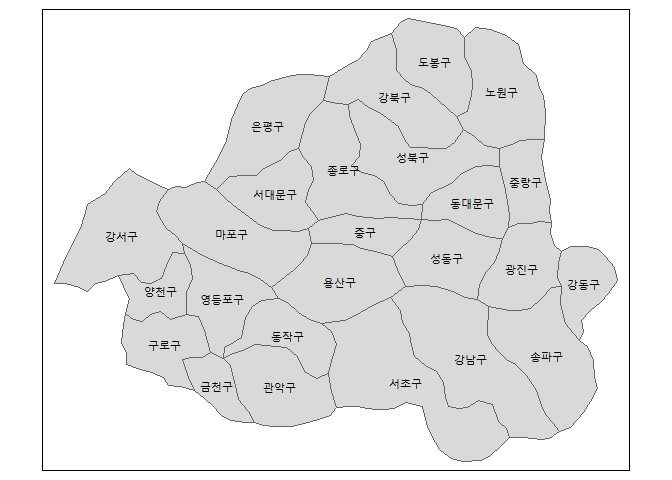

```r
qtm(seoul0, text = "name", text.size = 0.7)
```

# 자료 결합

## CSV 외부 화일 읽어오기와 자료의 결합

이제 2017년 구별 가구수 자료를 외부화일에서 불러들여 지도자료와 결합해 보자.

cvs 화일 **seoul-house.csv**에 저장된 인구자료를 데이터프레임 `house`에 불러온다.

```r
house <- read.table("seoul-house-win.csv", sep=",", header = TRUE)
head(house, n=5)
```

```
##     name  house
## 1 종로구  73735
## 2   중구  61502
## 3 용산구 108974
## 4 성동구 137209
## 5 광진구 162606
```

```r
seoul0@data <- left_join(seoul0@data,house, by = "name")
head(seoul0@data, n=10)
```

```
##          code     engname     name  house
## 1  1132000000      Dobong   도봉구 138087
## 2  1123000000 Dong-daemun 동대문구 161820
## 3  1159000000     Dongjak   동작구 177176
## 4  1138000000  Eun-pyeong   은평구 205001
## 5  1174000000     Gandong   강동구 177247
## 6  1130500000     Gangbuk   강북구 143395
## 7  1168000000     Gangnam   강남구 228775
## 8  1150000000     Gangseo   강서구 258503
## 9  1154500000  Geum-cheon   금천구 107971
## 10 1153000000        Guro   구로구 172457
```

## 지도 그리기

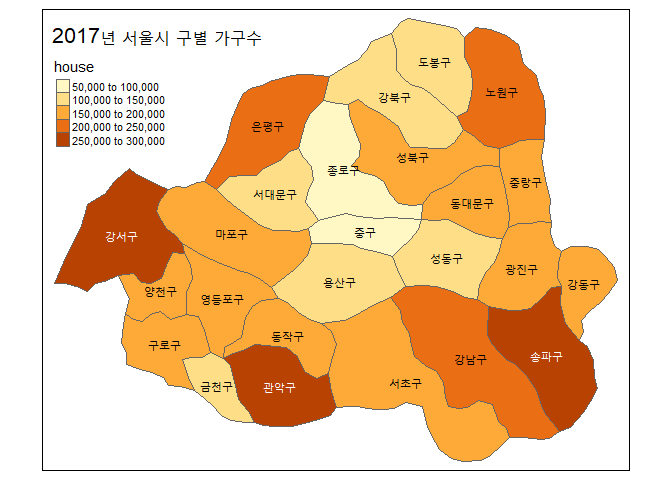

```r
qtm (seoul0,  fill ="house", text = "name", title="2017년 서울시 구별 가구수", text.size = 0.7)
```